# The old normal

NDH802 - Spring 2021

### Exercise 5.27

First, type in the assumptions from the question. Here I divide the $\mu$ and $\sigma$ by 1000 for presentation purpose only. Therefore I will work on ’000 SEK going forward, i.e., when you see 500, it means 500,000 SEK. You can totally skip this step if you want to.

```r
mu = 500000/1000
sigma = 50000/1000
```

**(a) What is the probability that the cost of building a home will be between $460,000 and $540,000? That is, $P(460,000 < X < 540,000)$ where $X$ denotes the cost?**  
What we want to compute is the *blue* area. To do that in base R, one way is to compute the grey area (which is $F(b)$ in Lecture 4 - slide 6), then subtract the pink area (which is $F(a)$ in Lecture 4 - slide 6) from it.

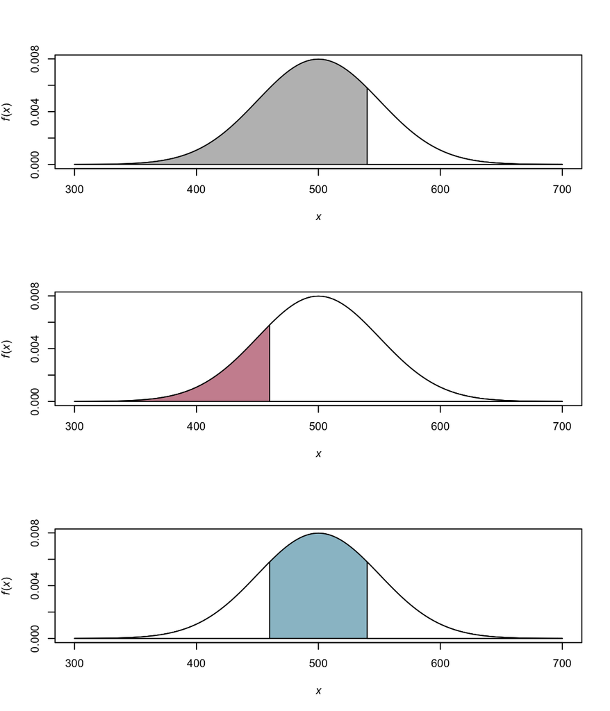

To compute the area below the normal curve, we use `pnorm()`.

```r
grey = pnorm(540, mean = mu, sd = sigma)
pink = pnorm(460, mean = mu, sd = sigma)
blue = grey - pink; cat(blue)
```

```
## 0.5762892
```

*Can you suggest another way to compute the blue area?*  
Hint: The total area below the normal curve is 1 and `pnorm()` can compute the area from either tails. Try `?pnorm` and check out the argument `lower.tail`.

```r
blue_alternative <- 1 - #total area below the curve
  pnorm(460, mean = mu, sd = sigma) - #the white area on the left
  pnorm(540, mean = mu, sd = sigma, lower.tail = FALSE) #the white area on the right
cat(blue_alternative)
```

```
## 0.5762892
```

**(b) What probability is 0.2 that the cost of building will be less than what amount? That is, find $a$ such that $P(X < a) = 0.2$?**

```r
a = qnorm(0.2, mean = mu, sd = sigma)
cat(a)
```

```
## 457.9189
```

**(c) Find the shortest range such that the probability is 0.95 that the cost of a luxury home will fall in this range. That is, find $b$ and $c$ such that $P(b < X < c) = 0.95$?**  
The graph is, again, for illustration purpose, you don’t need to learn to code it.  
Notice the lavendar area is 0.95.

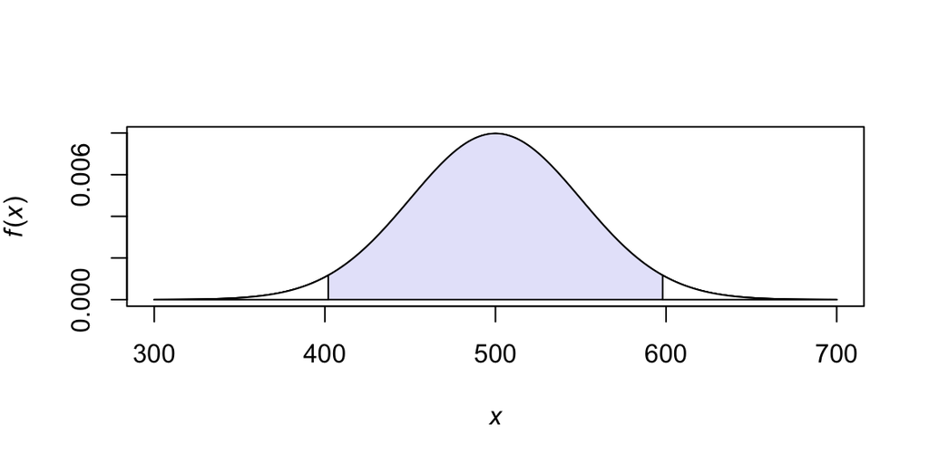

```r
b = qnorm(0.025, mean = mu, sd = sigma)
c = qnorm(0.975, mean = mu, sd = sigma)
shade.norm(from = b, to = c, sigma=sigma, mu=mu, tail="middle", show.dist = F, show.p = F, shade.col = "lavender")
```

*NOTE*  
- In (a), we compute the **area** below the curve (the grey/pink/blue area) which characterizes the **probability**.  
- In (b) and (c), we compute the **value** of $X$ (a point on the x-axis) which characterizes **the cost of building a home**.